# Risk Factor Analysis

## Outcome Variable

**Outcome Variable:** stunted

## Predictor Variables

**Intervention Variable:** parity

**Adjustment Set:**

unadjusted

## Stratifying Variables

The analysis was stratified on these variable(s):

- agecat
- studyid
- country

## Data Summary

| agecat | studyid | country | parity | stunted | n_cell | n |
| --- | --- | --- | --- | --- | --- | --- |
| Birth | ki1000304b-SAS-CompFeed | INDIA | 1 | 0 | 34 | 187 |
| Birth | ki1000304b-SAS-CompFeed | INDIA | 1 | 1 | 13 | 187 |
| Birth | ki1000304b-SAS-CompFeed | INDIA | 2 | 0 | 37 | 187 |
| Birth | ki1000304b-SAS-CompFeed | INDIA | 2 | 1 | 16 | 187 |
| Birth | ki1000304b-SAS-CompFeed | INDIA | 3+ | 0 | 70 | 187 |
| Birth | ki1000304b-SAS-CompFeed | INDIA | 3+ | 1 | 17 | 187 |
| Birth | ki1101329-Keneba | GAMBIA | 1 | 0 | 140 | 1407 |
| Birth | ki1101329-Keneba | GAMBIA | 1 | 1 | 16 | 1407 |
| Birth | ki1101329-Keneba | GAMBIA | 2 | 0 | 138 | 1407 |
| Birth | ki1101329-Keneba | GAMBIA | 2 | 1 | 8 | 1407 |
| Birth | ki1101329-Keneba | GAMBIA | 3+ | 0 | 1054 | 1407 |
| Birth | ki1101329-Keneba | GAMBIA | 3+ | 1 | 51 | 1407 |
| Birth | ki1126311-ZVITAMBO | ZIMBABWE | 1 | 0 | 5332 | 13829 |
| Birth | ki1126311-ZVITAMBO | ZIMBABWE | 1 | 1 | 640 | 13829 |
| Birth | ki1126311-ZVITAMBO | ZIMBABWE | 2 | 0 | 3718 | 13829 |
| Birth | ki1126311-ZVITAMBO | ZIMBABWE | 2 | 1 | 407 | 13829 |
| Birth | ki1126311-ZVITAMBO | ZIMBABWE | 3+ | 0 | 3347 | 13829 |
| Birth | ki1126311-ZVITAMBO | ZIMBABWE | 3+ | 1 | 385 | 13829 |
| Birth | ki1135781-COHORTS | GUATEMALA | 1 | 0 | 103 | 852 |
| Birth | ki1135781-COHORTS | GUATEMALA | 1 | 1 | 9 | 852 |
| Birth | ki1135781-COHORTS | GUATEMALA | 2 | 0 | 124 | 852 |
| Birth | ki1135781-COHORTS | GUATEMALA | 2 | 1 | 13 | 852 |
| Birth | ki1135781-COHORTS | GUATEMALA | 3+ | 0 | 575 | 852 |
| Birth | ki1135781-COHORTS | GUATEMALA | 3+ | 1 | 28 | 852 |
| Birth | ki1135781-COHORTS | INDIA | 1 | 0 | 582 | 4122 |
| Birth | ki1135781-COHORTS | INDIA | 1 | 1 | 114 | 4122 |
| Birth | ki1135781-COHORTS | INDIA | 2 | 0 | 939 | 4122 |
| Birth | ki1135781-COHORTS | INDIA | 2 | 1 | 98 | 4122 |
| Birth | ki1135781-COHORTS | INDIA | 3+ | 0 | 2126 | 4122 |
| Birth | ki1135781-COHORTS | INDIA | 3+ | 1 | 263 | 4122 |

[output cut: 132 more lines]

The following strata were considered:

- agecat: 24 months, studyid: ki1017093b-PROVIDE, country: BANGLADESH
- agecat: 24 months, studyid: ki1066203-TanzaniaChild2, country: TANZANIA, UNITED REPUBLIC OF
- agecat: 24 months, studyid: ki1101329-Keneba, country: GAMBIA
- agecat: 24 months, studyid: ki1113344-GMS-Nepal, country: NEPAL
- agecat: 24 months, studyid: ki1126311-ZVITAMBO, country: ZIMBABWE
- agecat: 24 months, studyid: ki1135781-COHORTS, country: GUATEMALA
- agecat: 24 months, studyid: ki1135781-COHORTS, country: INDIA
- agecat: 24 months, studyid: ki1135781-COHORTS, country: PHILIPPINES
- agecat: 24 months, studyid: kiGH5241-JiVitA-3, country: BANGLADESH
- agecat: 6 months, studyid: ki1000304b-SAS-CompFeed, country: INDIA
- agecat: 6 months, studyid: ki1000304b-SAS-FoodSuppl, country: INDIA
- agecat: 6 months, studyid: ki1017093b-PROVIDE, country: BANGLADESH
- agecat: 6 months, studyid: ki1066203-TanzaniaChild2, country: TANZANIA, UNITED REPUBLIC OF
- agecat: 6 months, studyid: ki1101329-Keneba, country: GAMBIA
- agecat: 6 months, studyid: ki1113344-GMS-Nepal, country: NEPAL
- agecat: 6 months, studyid: ki1126311-ZVITAMBO, country: ZIMBABWE
- agecat: 6 months, studyid: ki1135781-COHORTS, country: GUATEMALA
- agecat: 6 months, studyid: ki1135781-COHORTS, country: INDIA
- agecat: 6 months, studyid: ki1135781-COHORTS, country: PHILIPPINES
- agecat: 6 months, studyid: kiGH5241-JiVitA-3, country: BANGLADESH
- agecat: Birth, studyid: ki1000304b-SAS-CompFeed, country: INDIA
- agecat: Birth, studyid: ki1101329-Keneba, country: GAMBIA
- agecat: Birth, studyid: ki1126311-ZVITAMBO, country: ZIMBABWE
- agecat: Birth, studyid: ki1135781-COHORTS, country: GUATEMALA
- agecat: Birth, studyid: ki1135781-COHORTS, country: INDIA
- agecat: Birth, studyid: ki1135781-COHORTS, country: PHILIPPINES
- agecat: Birth, studyid: kiGH5241-JiVitA-3, country: BANGLADESH

### Dropped Strata

Some strata were dropped due to rare outcomes:

- agecat: 24 months, studyid: ki1066203-TanzaniaChild2, country: TANZANIA, UNITED REPUBLIC OF

## Methods Detail

We’re interested in the causal parameters $E[Y_a]$ for all values of $a \in \mathcal{A}$. These parameters represent the mean outcome if, possibly contrary to fact, we intervened to set all units to have $A=a$. Under the randomization and positivity assumptions, these are identified by the statistical parameters $\psi_a=E_W[E_{Y|A,W}(Y|A=a,W)]$. In addition, we’re interested in the mean of $Y$, $E[Y]$ under no intervention (the observed mean). We will estimate these parameters by using SuperLearner to fit the relevant likelihood factors – $E_{Y|A,W}(Y|A=a,W)$ and $p(A=a|W)$, and then updating our likelihood fit using a joint TMLE.

For unadjusted analyses ($W=\{\}$), initial likelihoods were estimated using Lrnr_glm to estimate the simple $E(Y|A)$ and Lrnr_mean to estimate $p(A)$. For adjusted analyses, a small library containing Lrnr_glmnet, Lrnr_xgboost, and Lrnr_mean was used.

Having estimated these parameters, we will then use the delta method to estimate relative risks and attributable risks relative to a prespecified baseline level of $A$.

# Results Detail

## Results Plots

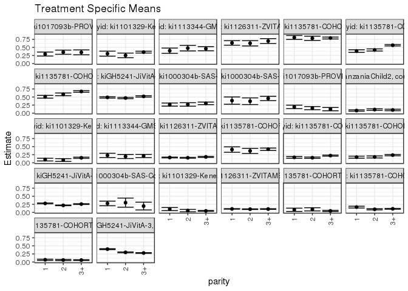

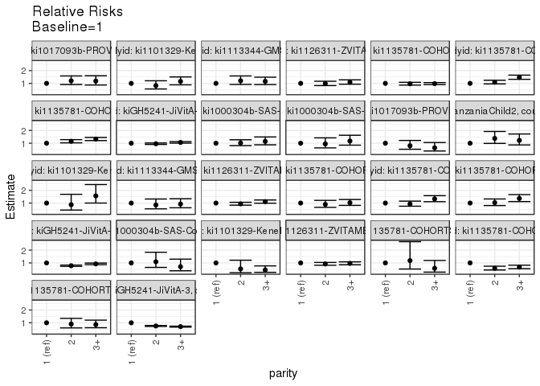

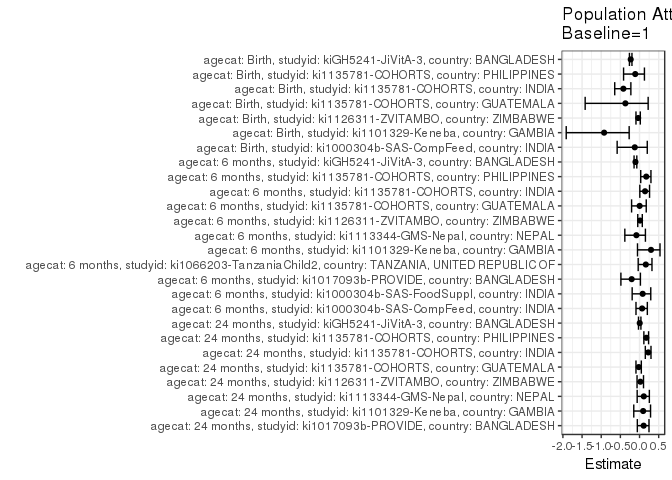

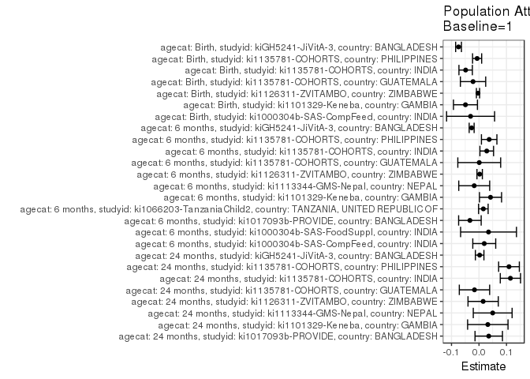

## Results Table

### Parameter: TSM

| agecat | studyid | country | intervention_level | baseline_level | estimate | ci_lower | ci_upper |
| --- | --- | --- | --- | --- | --- | --- | --- |
| Birth | ki1000304b-SAS-CompFeed | INDIA | 1 | NA | 0.2765957 | 0.2049471 | 0.3482444 |
| Birth | ki1000304b-SAS-CompFeed | INDIA | 2 | NA | 0.3018868 | 0.1608686 | 0.4429049 |
| Birth | ki1000304b-SAS-CompFeed | INDIA | 3+ | NA | 0.1954023 | 0.0747346 | 0.3160700 |
| Birth | ki1101329-Keneba | GAMBIA | 1 | NA | 0.1025641 | 0.0549386 | 0.1501896 |
| Birth | ki1101329-Keneba | GAMBIA | 2 | NA | 0.0547945 | 0.0178664 | 0.0917227 |
| Birth | ki1101329-Keneba | GAMBIA | 3+ | NA | 0.0461538 | 0.0337783 | 0.0585294 |
| Birth | ki1126311-ZVITAMBO | ZIMBABWE | 1 | NA | 0.1071668 | 0.0993213 | 0.1150123 |
| Birth | ki1126311-ZVITAMBO | ZIMBABWE | 2 | NA | 0.0986667 | 0.0895659 | 0.1077675 |
| Birth | ki1126311-ZVITAMBO | ZIMBABWE | 3+ | NA | 0.1031618 | 0.0934027 | 0.1129209 |
| Birth | ki1135781-COHORTS | GUATEMALA | 1 | NA | 0.0803571 | 0.0299820 | 0.1307322 |
| Birth | ki1135781-COHORTS | GUATEMALA | 2 | NA | 0.0948905 | 0.0457879 | 0.1439931 |
| Birth | ki1135781-COHORTS | GUATEMALA | 3+ | NA | 0.0464345 | 0.0296294 | 0.0632396 |
| Birth | ki1135781-COHORTS | INDIA | 1 | NA | 0.1637931 | 0.1362951 | 0.1912911 |
| Birth | ki1135781-COHORTS | INDIA | 2 | NA | 0.0945034 | 0.0766969 | 0.1123099 |
| Birth | ki1135781-COHORTS | INDIA | 3+ | NA | 0.1100879 | 0.0975352 | 0.1226406 |
| Birth | ki1135781-COHORTS | PHILIPPINES | 1 | NA | 0.0681481 | 0.0491344 | 0.0871619 |
| Birth | ki1135781-COHORTS | PHILIPPINES | 2 | NA | 0.0611354 | 0.0432174 | 0.0790533 |
| Birth | ki1135781-COHORTS | PHILIPPINES | 3+ | NA | 0.0586493 | 0.0474384 | 0.0698602 |
| Birth | kiGH5241-JiVitA-3 | BANGLADESH | 1 | NA | 0.3977037 | 0.3846150 | 0.4107924 |
| Birth | kiGH5241-JiVitA-3 | BANGLADESH | 2 | NA | 0.2979136 | 0.2852440 | 0.3105831 |
| Birth | kiGH5241-JiVitA-3 | BANGLADESH | 3+ | NA | 0.2783910 | 0.2667455 | 0.2900366 |
| 6 months | ki1000304b-SAS-CompFeed | INDIA | 1 | NA | 0.2653061 | 0.2173742 | 0.3132380 |
| 6 months | ki1000304b-SAS-CompFeed | INDIA | 2 | NA | 0.2697368 | 0.2160109 | 0.3234628 |
| 6 months | ki1000304b-SAS-CompFeed | INDIA | 3+ | NA | 0.3031250 | 0.2636267 | 0.3426233 |
| 6 months | ki1000304b-SAS-FoodSuppl | INDIA | 1 | NA | 0.3888889 | 0.2761334 | 0.5016444 |
| 6 months | ki1000304b-SAS-FoodSuppl | INDIA | 2 | NA | 0.3690476 | 0.2657166 | 0.4723787 |
| 6 months | ki1000304b-SAS-FoodSuppl | INDIA | 3+ | NA | 0.4562212 | 0.3898622 | 0.5225802 |
| 6 months | ki1017093b-PROVIDE | BANGLADESH | 1 | NA | 0.1943128 | 0.1408793 | 0.2477463 |
| 6 months | ki1017093b-PROVIDE | BANGLADESH | 2 | NA | 0.1556604 | 0.1068176 | 0.2045032 |
| 6 months | ki1017093b-PROVIDE | BANGLADESH | 3+ | NA | 0.1250000 | 0.0737115 | 0.1762885 |
| 6 months | ki1066203-TanzaniaChild2 | TANZANIA, UNITED REPUBLIC OF | 1 | NA | 0.0808824 | 0.0603842 | 0.1013805 |
| 6 months | ki1066203-TanzaniaChild2 | TANZANIA, UNITED REPUBLIC OF | 2 | NA | 0.1111111 | 0.0870743 | 0.1351479 |
| 6 months | ki1066203-TanzaniaChild2 | TANZANIA, UNITED REPUBLIC OF | 3+ | NA | 0.0987842 | 0.0759807 | 0.1215877 |
| 6 months | ki1101329-Keneba | GAMBIA | 1 | NA | 0.0979381 | 0.0560997 | 0.1397766 |
| 6 months | ki1101329-Keneba | GAMBIA | 2 | NA | 0.0853659 | 0.0425874 | 0.1281444 |
| 6 months | ki1101329-Keneba | GAMBIA | 3+ | NA | 0.1533597 | 0.1334968 | 0.1732225 |
| 6 months | ki1113344-GMS-Nepal | NEPAL | 1 | NA | 0.2287582 | 0.1621432 | 0.2953732 |
| 6 months | ki1113344-GMS-Nepal | NEPAL | 2 | NA | 0.1946309 | 0.1310034 | 0.2582583 |
| 6 months | ki1113344-GMS-Nepal | NEPAL | 3+ | NA | 0.2107280 | 0.1612071 | 0.2602488 |
| 6 months | ki1126311-ZVITAMBO | ZIMBABWE | 1 | NA | 0.1638401 | 0.1512148 | 0.1764654 |
| 6 months | ki1126311-ZVITAMBO | ZIMBABWE | 2 | NA | 0.1542427 | 0.1401457 | 0.1683397 |
| 6 months | ki1126311-ZVITAMBO | ZIMBABWE | 3+ | NA | 0.1817814 | 0.1665712 | 0.1969916 |
| 6 months | ki1135781-COHORTS | GUATEMALA | 1 | NA | 0.4090909 | 0.3251725 | 0.4930094 |
| 6 months | ki1135781-COHORTS | GUATEMALA | 2 | NA | 0.3669065 | 0.2867427 | 0.4470703 |
| 6 months | ki1135781-COHORTS | GUATEMALA | 3+ | NA | 0.4188406 | 0.3820089 | 0.4556723 |
| 6 months | ki1135781-COHORTS | INDIA | 1 | NA | 0.1675676 | 0.1406552 | 0.1944800 |
| 6 months | ki1135781-COHORTS | INDIA | 2 | NA | 0.1560219 | 0.1345361 | 0.1775077 |
| 6 months | ki1135781-COHORTS | INDIA | 3+ | NA | 0.2219959 | 0.2055546 | 0.2384372 |
| 6 months | ki1135781-COHORTS | PHILIPPINES | 1 | NA | 0.1742160 | 0.1431812 | 0.2052509 |
| 6 months | ki1135781-COHORTS | PHILIPPINES | 2 | NA | 0.1798680 | 0.1492828 | 0.2104531 |
| 6 months | ki1135781-COHORTS | PHILIPPINES | 3+ | NA | 0.2375654 | 0.2162222 | 0.2589086 |
| 6 months | kiGH5241-JiVitA-3 | BANGLADESH | 1 | NA | 0.2781483 | 0.2655096 | 0.2907870 |
| 6 months | kiGH5241-JiVitA-3 | BANGLADESH | 2 | NA | 0.2170325 | 0.2056218 | 0.2284432 |
| 6 months | kiGH5241-JiVitA-3 | BANGLADESH | 3+ | NA | 0.2568428 | 0.2427135 | 0.2709721 |
| 24 months | ki1017093b-PROVIDE | BANGLADESH | 1 | NA | 0.2938389 | 0.2323226 | 0.3553551 |
| 24 months | ki1017093b-PROVIDE | BANGLADESH | 2 | NA | 0.3521127 | 0.2879141 | 0.4163113 |
| 24 months | ki1017093b-PROVIDE | BANGLADESH | 3+ | NA | 0.3464052 | 0.2709437 | 0.4218667 |
| 24 months | ki1101329-Keneba | GAMBIA | 1 | NA | 0.3065693 | 0.2293348 | 0.3838039 |
| 24 months | ki1101329-Keneba | GAMBIA | 2 | NA | 0.2517986 | 0.1796156 | 0.3239815 |
| 24 months | ki1101329-Keneba | GAMBIA | 3+ | NA | 0.3536364 | 0.3253728 | 0.3818999 |
| 24 months | ki1113344-GMS-Nepal | NEPAL | 1 | NA | 0.3970588 | 0.3147438 | 0.4793739 |
| 24 months | ki1113344-GMS-Nepal | NEPAL | 2 | NA | 0.4769231 | 0.3909784 | 0.5628678 |
| 24 months | ki1113344-GMS-Nepal | NEPAL | 3+ | NA | 0.4592275 | 0.3951763 | 0.5232786 |
| 24 months | ki1126311-ZVITAMBO | ZIMBABWE | 1 | NA | 0.6384181 | 0.5675592 | 0.7092769 |
| 24 months | ki1126311-ZVITAMBO | ZIMBABWE | 2 | NA | 0.6268657 | 0.5448886 | 0.7088427 |
| 24 months | ki1126311-ZVITAMBO | ZIMBABWE | 3+ | NA | 0.6965517 | 0.6216383 | 0.7714652 |
| 24 months | ki1135781-COHORTS | GUATEMALA | 1 | NA | 0.8083832 | 0.7486634 | 0.8681031 |
| 24 months | ki1135781-COHORTS | GUATEMALA | 2 | NA | 0.7814570 | 0.7155116 | 0.8474023 |
| 24 months | ki1135781-COHORTS | GUATEMALA | 3+ | NA | 0.7903872 | 0.7612237 | 0.8195507 |
| 24 months | ki1135781-COHORTS | INDIA | 1 | NA | 0.3858407 | 0.3456956 | 0.4259858 |
| 24 months | ki1135781-COHORTS | INDIA | 2 | NA | 0.4211765 | 0.3879788 | 0.4543742 |
| 24 months | ki1135781-COHORTS | INDIA | 3+ | NA | 0.5670732 | 0.5451791 | 0.5889672 |
| 24 months | ki1135781-COHORTS | PHILIPPINES | 1 | NA | 0.5076336 | 0.4648191 | 0.5504481 |
| 24 months | ki1135781-COHORTS | PHILIPPINES | 2 | NA | 0.5827206 | 0.5412747 | 0.6241664 |
| 24 months | ki1135781-COHORTS | PHILIPPINES | 3+ | NA | 0.6717502 | 0.6469431 | 0.6965573 |
| 24 months | kiGH5241-JiVitA-3 | BANGLADESH | 1 | NA | 0.4884274 | 0.4676510 | 0.5092038 |
| 24 months | kiGH5241-JiVitA-3 | BANGLADESH | 2 | NA | 0.4688946 | 0.4483589 | 0.4894303 |
| 24 months | kiGH5241-JiVitA-3 | BANGLADESH | 3+ | NA | 0.5190448 | 0.4975454 | 0.5405442 |

### Parameter: E(Y)

| agecat | studyid | country | intervention_level | baseline_level | estimate | ci_lower | ci_upper |
| --- | --- | --- | --- | --- | --- | --- | --- |
| Birth | ki1000304b-SAS-CompFeed | INDIA | NA | NA | 0.2459893 | 0.1594019 | 0.3325767 |
| Birth | ki1101329-Keneba | GAMBIA | NA | NA | 0.0533049 | 0.0415629 | 0.0650470 |
| Birth | ki1126311-ZVITAMBO | ZIMBABWE | NA | NA | 0.1035505 | 0.0984723 | 0.1086287 |
| Birth | ki1135781-COHORTS | GUATEMALA | NA | NA | 0.0586854 | 0.0428942 | 0.0744767 |
| Birth | ki1135781-COHORTS | INDIA | NA | NA | 0.1152353 | 0.1054865 | 0.1249842 |
| Birth | ki1135781-COHORTS | PHILIPPINES | NA | NA | 0.0613115 | 0.0527962 | 0.0698268 |
| Birth | kiGH5241-JiVitA-3 | BANGLADESH | NA | NA | 0.3232622 | 0.3156056 | 0.3309189 |
| 6 months | ki1000304b-SAS-CompFeed | INDIA | NA | NA | 0.2844311 | 0.2666491 | 0.3022132 |
| 6 months | ki1000304b-SAS-FoodSuppl | INDIA | NA | NA | 0.4235925 | 0.3733796 | 0.4738054 |
| 6 months | ki1017093b-PROVIDE | BANGLADESH | NA | NA | 0.1612350 | 0.1313580 | 0.1911120 |
| 6 months | ki1066203-TanzaniaChild2 | TANZANIA, UNITED REPUBLIC OF | NA | NA | 0.0967419 | 0.0837671 | 0.1097166 |
| 6 months | ki1101329-Keneba | GAMBIA | NA | NA | 0.1398645 | 0.1229849 | 0.1567440 |
| 6 months | ki1113344-GMS-Nepal | NEPAL | NA | NA | 0.2113677 | 0.1776128 | 0.2451225 |
| 6 months | ki1126311-ZVITAMBO | ZIMBABWE | NA | NA | 0.1662648 | 0.1582516 | 0.1742780 |
| 6 months | ki1135781-COHORTS | GUATEMALA | NA | NA | 0.4099896 | 0.3788775 | 0.4411017 |
| 6 months | ki1135781-COHORTS | INDIA | NA | NA | 0.1957586 | 0.1838852 | 0.2076319 |
| 6 months | ki1135781-COHORTS | PHILIPPINES | NA | NA | 0.2112260 | 0.1958496 | 0.2266024 |
| 6 months | kiGH5241-JiVitA-3 | BANGLADESH | NA | NA | 0.2514228 | 0.2432969 | 0.2595487 |
| 24 months | ki1017093b-PROVIDE | BANGLADESH | NA | NA | 0.3292894 | 0.2909105 | 0.3676684 |
| 24 months | ki1101329-Keneba | GAMBIA | NA | NA | 0.3386628 | 0.3136483 | 0.3636773 |
| 24 months | ki1113344-GMS-Nepal | NEPAL | NA | NA | 0.4468938 | 0.4032281 | 0.4905594 |
| 24 months | ki1126311-ZVITAMBO | ZIMBABWE | NA | NA | 0.6535088 | 0.6097853 | 0.6972322 |
| 24 months | ki1135781-COHORTS | GUATEMALA | NA | NA | 0.7919400 | 0.7675726 | 0.8163075 |
| 24 months | ki1135781-COHORTS | INDIA | NA | NA | 0.5001478 | 0.4832966 | 0.5169990 |
| 24 months | ki1135781-COHORTS | PHILIPPINES | NA | NA | 0.6167689 | 0.5974942 | 0.6360437 |
| 24 months | kiGH5241-JiVitA-3 | BANGLADESH | NA | NA | 0.4908193 | 0.4776993 | 0.5039392 |

### Parameter: RR

| agecat | studyid | country | intervention_level | baseline_level | estimate | ci_lower | ci_upper |
| --- | --- | --- | --- | --- | --- | --- | --- |
| Birth | ki1000304b-SAS-CompFeed | INDIA | 1 | 1 | 1.0000000 | 1.0000000 | 1.0000000 |
| Birth | ki1000304b-SAS-CompFeed | INDIA | 2 | 1 | 1.0914369 | 0.6496948 | 1.8335292 |
| Birth | ki1000304b-SAS-CompFeed | INDIA | 3+ | 1 | 0.7064545 | 0.3846998 | 1.2973177 |
| Birth | ki1101329-Keneba | GAMBIA | 1 | 1 | 1.0000000 | 1.0000000 | 1.0000000 |
| Birth | ki1101329-Keneba | GAMBIA | 2 | 1 | 0.5342466 | 0.2356709 | 1.2110933 |
| Birth | ki1101329-Keneba | GAMBIA | 3+ | 1 | 0.4500000 | 0.2632335 | 0.7692791 |
| Birth | ki1126311-ZVITAMBO | ZIMBABWE | 1 | 1 | 1.0000000 | 1.0000000 | 1.0000000 |
| Birth | ki1126311-ZVITAMBO | ZIMBABWE | 2 | 1 | 0.9206833 | 0.8184046 | 1.0357442 |
| Birth | ki1126311-ZVITAMBO | ZIMBABWE | 3+ | 1 | 0.9626290 | 0.8541012 | 1.0849470 |
| Birth | ki1135781-COHORTS | GUATEMALA | 1 | 1 | 1.0000000 | 1.0000000 | 1.0000000 |
| Birth | ki1135781-COHORTS | GUATEMALA | 2 | 1 | 1.1808597 | 0.5238079 | 2.6621012 |
| Birth | ki1135781-COHORTS | GUATEMALA | 3+ | 1 | 0.5778515 | 0.2801877 | 1.1917454 |
| Birth | ki1135781-COHORTS | INDIA | 1 | 1 | 1.0000000 | 1.0000000 | 1.0000000 |
| Birth | ki1135781-COHORTS | INDIA | 2 | 1 | 0.5769680 | 0.4482824 | 0.7425945 |
| Birth | ki1135781-COHORTS | INDIA | 3+ | 1 | 0.6721156 | 0.5486645 | 0.8233437 |
| Birth | ki1135781-COHORTS | PHILIPPINES | 1 | 1 | 1.0000000 | 1.0000000 | 1.0000000 |
| Birth | ki1135781-COHORTS | PHILIPPINES | 2 | 1 | 0.8970951 | 0.5985491 | 1.3445507 |
| Birth | ki1135781-COHORTS | PHILIPPINES | 3+ | 1 | 0.8606146 | 0.6136598 | 1.2069511 |
| Birth | kiGH5241-JiVitA-3 | BANGLADESH | 1 | 1 | 1.0000000 | 1.0000000 | 1.0000000 |
| Birth | kiGH5241-JiVitA-3 | BANGLADESH | 2 | 1 | 0.7490842 | 0.7106662 | 0.7895790 |
| Birth | kiGH5241-JiVitA-3 | BANGLADESH | 3+ | 1 | 0.6999961 | 0.6643907 | 0.7375096 |
| 6 months | ki1000304b-SAS-CompFeed | INDIA | 1 | 1 | 1.0000000 | 1.0000000 | 1.0000000 |
| 6 months | ki1000304b-SAS-CompFeed | INDIA | 2 | 1 | 1.0167004 | 0.8134162 | 1.2707882 |
| 6 months | ki1000304b-SAS-CompFeed | INDIA | 3+ | 1 | 1.1425481 | 0.8761040 | 1.4900241 |
| 6 months | ki1000304b-SAS-FoodSuppl | INDIA | 1 | 1 | 1.0000000 | 1.0000000 | 1.0000000 |
| 6 months | ki1000304b-SAS-FoodSuppl | INDIA | 2 | 1 | 0.9489796 | 0.6341718 | 1.4200604 |
| 6 months | ki1000304b-SAS-FoodSuppl | INDIA | 3+ | 1 | 1.1731402 | 0.8481501 | 1.6226585 |
| 6 months | ki1017093b-PROVIDE | BANGLADESH | 1 | 1 | 1.0000000 | 1.0000000 | 1.0000000 |
| 6 months | ki1017093b-PROVIDE | BANGLADESH | 2 | 1 | 0.8010815 | 0.5278121 | 1.2158333 |
| 6 months | ki1017093b-PROVIDE | BANGLADESH | 3+ | 1 | 0.6432927 | 0.3925509 | 1.0541958 |
| 6 months | ki1066203-TanzaniaChild2 | TANZANIA, UNITED REPUBLIC OF | 1 | 1 | 1.0000000 | 1.0000000 | 1.0000000 |
| 6 months | ki1066203-TanzaniaChild2 | TANZANIA, UNITED REPUBLIC OF | 2 | 1 | 1.3737374 | 0.9844502 | 1.9169628 |
| 6 months | ki1066203-TanzaniaChild2 | TANZANIA, UNITED REPUBLIC OF | 3+ | 1 | 1.2213319 | 0.8668722 | 1.7207282 |
| 6 months | ki1101329-Keneba | GAMBIA | 1 | 1 | 1.0000000 | 1.0000000 | 1.0000000 |
| 6 months | ki1101329-Keneba | GAMBIA | 2 | 1 | 0.8716305 | 0.4511824 | 1.6838859 |
| 6 months | ki1101329-Keneba | GAMBIA | 3+ | 1 | 1.5658831 | 1.0020575 | 2.4469551 |
| 6 months | ki1113344-GMS-Nepal | NEPAL | 1 | 1 | 1.0000000 | 1.0000000 | 1.0000000 |
| 6 months | ki1113344-GMS-Nepal | NEPAL | 2 | 1 | 0.8508150 | 0.5491611 | 1.3181671 |
| 6 months | ki1113344-GMS-Nepal | NEPAL | 3+ | 1 | 0.9211823 | 0.6336271 | 1.3392368 |
| 6 months | ki1126311-ZVITAMBO | ZIMBABWE | 1 | 1 | 1.0000000 | 1.0000000 | 1.0000000 |
| 6 months | ki1126311-ZVITAMBO | ZIMBABWE | 2 | 1 | 0.9414220 | 0.8353462 | 1.0609676 |
| 6 months | ki1126311-ZVITAMBO | ZIMBABWE | 3+ | 1 | 1.1095048 | 0.9902115 | 1.2431698 |
| 6 months | ki1135781-COHORTS | GUATEMALA | 1 | 1 | 1.0000000 | 1.0000000 | 1.0000000 |
| 6 months | ki1135781-COHORTS | GUATEMALA | 2 | 1 | 0.8968825 | 0.6646308 | 1.2102932 |
| 6 months | ki1135781-COHORTS | GUATEMALA | 3+ | 1 | 1.0238325 | 0.8190296 | 1.2798476 |
| 6 months | ki1135781-COHORTS | INDIA | 1 | 1 | 1.0000000 | 1.0000000 | 1.0000000 |
| 6 months | ki1135781-COHORTS | INDIA | 2 | 1 | 0.9310984 | 0.7535558 | 1.1504713 |
| 6 months | ki1135781-COHORTS | INDIA | 3+ | 1 | 1.3248144 | 1.1100582 | 1.5811182 |
| 6 months | ki1135781-COHORTS | PHILIPPINES | 1 | 1 | 1.0000000 | 1.0000000 | 1.0000000 |
| 6 months | ki1135781-COHORTS | PHILIPPINES | 2 | 1 | 1.0324422 | 0.8070727 | 1.3207447 |
| 6 months | ki1135781-COHORTS | PHILIPPINES | 3+ | 1 | 1.3636257 | 1.1169864 | 1.6647248 |
| 6 months | kiGH5241-JiVitA-3 | BANGLADESH | 1 | 1 | 1.0000000 | 1.0000000 | 1.0000000 |
| 6 months | kiGH5241-JiVitA-3 | BANGLADESH | 2 | 1 | 0.7802762 | 0.7320390 | 0.8316919 |
| 6 months | kiGH5241-JiVitA-3 | BANGLADESH | 3+ | 1 | 0.9234023 | 0.8623684 | 0.9887558 |
| 24 months | ki1017093b-PROVIDE | BANGLADESH | 1 | 1 | 1.0000000 | 1.0000000 | 1.0000000 |
| 24 months | ki1017093b-PROVIDE | BANGLADESH | 2 | 1 | 1.1983189 | 0.9078310 | 1.5817573 |
| 24 months | ki1017093b-PROVIDE | BANGLADESH | 3+ | 1 | 1.1788952 | 0.8714866 | 1.5947392 |
| 24 months | ki1101329-Keneba | GAMBIA | 1 | 1 | 1.0000000 | 1.0000000 | 1.0000000 |
| 24 months | ki1101329-Keneba | GAMBIA | 2 | 1 | 0.8213429 | 0.5607645 | 1.2030081 |
| 24 months | ki1101329-Keneba | GAMBIA | 3+ | 1 | 1.1535281 | 0.8856088 | 1.5024999 |
| 24 months | ki1113344-GMS-Nepal | NEPAL | 1 | 1 | 1.0000000 | 1.0000000 | 1.0000000 |
| 24 months | ki1113344-GMS-Nepal | NEPAL | 2 | 1 | 1.2011396 | 0.9126383 | 1.5808414 |
| 24 months | ki1113344-GMS-Nepal | NEPAL | 3+ | 1 | 1.1565729 | 0.9008628 | 1.4848662 |
| 24 months | ki1126311-ZVITAMBO | ZIMBABWE | 1 | 1 | 1.0000000 | 1.0000000 | 1.0000000 |
| 24 months | ki1126311-ZVITAMBO | ZIMBABWE | 2 | 1 | 0.9819046 | 0.8271365 | 1.1656319 |
| 24 months | ki1126311-ZVITAMBO | ZIMBABWE | 3+ | 1 | 1.0910589 | 0.9348195 | 1.2734111 |
| 24 months | ki1135781-COHORTS | GUATEMALA | 1 | 1 | 1.0000000 | 1.0000000 | 1.0000000 |
| 24 months | ki1135781-COHORTS | GUATEMALA | 2 | 1 | 0.9666912 | 0.8641301 | 1.0814249 |
| 24 months | ki1135781-COHORTS | GUATEMALA | 3+ | 1 | 0.9777382 | 0.9002427 | 1.0619048 |
| 24 months | ki1135781-COHORTS | INDIA | 1 | 1 | 1.0000000 | 1.0000000 | 1.0000000 |
| 24 months | ki1135781-COHORTS | INDIA | 2 | 1 | 1.0915812 | 0.9580037 | 1.2437839 |
| 24 months | ki1135781-COHORTS | INDIA | 3+ | 1 | 1.4697080 | 1.3153272 | 1.6422085 |
| 24 months | ki1135781-COHORTS | PHILIPPINES | 1 | 1 | 1.0000000 | 1.0000000 | 1.0000000 |
| 24 months | ki1135781-COHORTS | PHILIPPINES | 2 | 1 | 1.1479157 | 1.0280052 | 1.2818131 |
| 24 months | ki1135781-COHORTS | PHILIPPINES | 3+ | 1 | 1.3232974 | 1.2068997 | 1.4509208 |
| 24 months | kiGH5241-JiVitA-3 | BANGLADESH | 1 | 1 | 1.0000000 | 1.0000000 | 1.0000000 |
| 24 months | kiGH5241-JiVitA-3 | BANGLADESH | 2 | 1 | 0.9600088 | 0.9054561 | 1.0178482 |
| 24 months | kiGH5241-JiVitA-3 | BANGLADESH | 3+ | 1 | 1.0626857 | 1.0038767 | 1.1249398 |

### Parameter: PAR

| agecat | studyid | country | intervention_level | baseline_level | estimate | ci_lower | ci_upper |
| --- | --- | --- | --- | --- | --- | --- | --- |
| Birth | ki1000304b-SAS-CompFeed | INDIA | 1 | NA | -0.0306064 | -0.1179593 | 0.0567464 |
| Birth | ki1101329-Keneba | GAMBIA | 1 | NA | -0.0492592 | -0.0928837 | -0.0056347 |
| Birth | ki1126311-ZVITAMBO | ZIMBABWE | 1 | NA | -0.0036163 | -0.0094624 | 0.0022299 |
| Birth | ki1135781-COHORTS | GUATEMALA | 1 | NA | -0.0216717 | -0.0677134 | 0.0243700 |
| Birth | ki1135781-COHORTS | INDIA | 1 | NA | -0.0485578 | -0.0729674 | -0.0241481 |
| Birth | ki1135781-COHORTS | PHILIPPINES | 1 | NA | -0.0068367 | -0.0233901 | 0.0097167 |
| Birth | kiGH5241-JiVitA-3 | BANGLADESH | 1 | NA | -0.0744415 | -0.0849705 | -0.0639124 |
| 6 months | ki1000304b-SAS-CompFeed | INDIA | 1 | NA | 0.0191250 | -0.0225940 | 0.0608440 |
| 6 months | ki1000304b-SAS-FoodSuppl | INDIA | 1 | NA | 0.0347036 | -0.0669176 | 0.1363248 |
| 6 months | ki1017093b-PROVIDE | BANGLADESH | 1 | NA | -0.0330778 | -0.0740790 | 0.0079234 |
| 6 months | ki1066203-TanzaniaChild2 | TANZANIA, UNITED REPUBLIC OF | 1 | NA | 0.0158595 | -0.0015211 | 0.0332401 |
| 6 months | ki1101329-Keneba | GAMBIA | 1 | NA | 0.0419263 | 0.0017156 | 0.0821370 |
| 6 months | ki1113344-GMS-Nepal | NEPAL | 1 | NA | -0.0173905 | -0.0736494 | 0.0388684 |
| 6 months | ki1126311-ZVITAMBO | ZIMBABWE | 1 | NA | 0.0024247 | -0.0074085 | 0.0122578 |
| 6 months | ki1135781-COHORTS | GUATEMALA | 1 | NA | 0.0008987 | -0.0770478 | 0.0788451 |
| 6 months | ki1135781-COHORTS | INDIA | 1 | NA | 0.0281910 | 0.0033828 | 0.0529991 |
| 6 months | ki1135781-COHORTS | PHILIPPINES | 1 | NA | 0.0370100 | 0.0088802 | 0.0651397 |
| 6 months | kiGH5241-JiVitA-3 | BANGLADESH | 1 | NA | -0.0267255 | -0.0357399 | -0.0177111 |
| 24 months | ki1017093b-PROVIDE | BANGLADESH | 1 | NA | 0.0354506 | -0.0144444 | 0.0853456 |
| 24 months | ki1101329-Keneba | GAMBIA | 1 | NA | 0.0320934 | -0.0414121 | 0.1055990 |
| 24 months | ki1113344-GMS-Nepal | NEPAL | 1 | NA | 0.0498350 | -0.0207982 | 0.1204682 |
| 24 months | ki1126311-ZVITAMBO | ZIMBABWE | 1 | NA | 0.0150907 | -0.0399988 | 0.0701802 |
| 24 months | ki1135781-COHORTS | GUATEMALA | 1 | NA | -0.0164432 | -0.0716142 | 0.0387277 |
| 24 months | ki1135781-COHORTS | INDIA | 1 | NA | 0.1143071 | 0.0774659 | 0.1511483 |
| 24 months | ki1135781-COHORTS | PHILIPPINES | 1 | NA | 0.1091353 | 0.0714673 | 0.1468034 |
| 24 months | kiGH5241-JiVitA-3 | BANGLADESH | 1 | NA | 0.0023919 | -0.0131419 | 0.0179257 |

### Parameter: PAF

| agecat | studyid | country | intervention_level | baseline_level | estimate | ci_lower | ci_upper |
| --- | --- | --- | --- | --- | --- | --- | --- |
| Birth | ki1000304b-SAS-CompFeed | INDIA | 1 | NA | -0.1244218 | -0.5841781 | 0.2019051 |
| Birth | ki1101329-Keneba | GAMBIA | 1 | NA | -0.9241025 | -1.9135260 | -0.2706839 |
| Birth | ki1126311-ZVITAMBO | ZIMBABWE | 1 | NA | -0.0349227 | -0.0929274 | 0.0200035 |
| Birth | ki1135781-COHORTS | GUATEMALA | 1 | NA | -0.3692857 | -1.4191803 | 0.2249675 |
| Birth | ki1135781-COHORTS | INDIA | 1 | NA | -0.4213793 | -0.6476006 | -0.2262190 |
| Birth | ki1135781-COHORTS | PHILIPPINES | 1 | NA | -0.1115072 | -0.4166265 | 0.1278941 |
| Birth | kiGH5241-JiVitA-3 | BANGLADESH | 1 | NA | -0.2302821 | -0.2636914 | -0.1977560 |
| 6 months | ki1000304b-SAS-CompFeed | INDIA | 1 | NA | 0.0672395 | -0.0924640 | 0.2035965 |
| 6 months | ki1000304b-SAS-FoodSuppl | INDIA | 1 | NA | 0.0819269 | -0.1923285 | 0.2930989 |
| 6 months | ki1017093b-PROVIDE | BANGLADESH | 1 | NA | -0.2051528 | -0.4863799 | 0.0228654 |
| 6 months | ki1066203-TanzaniaChild2 | TANZANIA, UNITED REPUBLIC OF | 1 | NA | 0.1639363 | -0.0351138 | 0.3247095 |
| 6 months | ki1101329-Keneba | GAMBIA | 1 | NA | 0.2997638 | -0.0530775 | 0.5343831 |
| 6 months | ki1113344-GMS-Nepal | NEPAL | 1 | NA | -0.0822760 | -0.3838537 | 0.1535800 |
| 6 months | ki1126311-ZVITAMBO | ZIMBABWE | 1 | NA | 0.0145832 | -0.0463663 | 0.0719825 |
| 6 months | ki1135781-COHORTS | GUATEMALA | 1 | NA | 0.0021920 | -0.2072456 | 0.1752955 |
| 6 months | ki1135781-COHORTS | INDIA | 1 | NA | 0.1440090 | 0.0076228 | 0.2616511 |
| 6 months | ki1135781-COHORTS | PHILIPPINES | 1 | NA | 0.1752150 | 0.0310883 | 0.2979027 |
| 6 months | kiGH5241-JiVitA-3 | BANGLADESH | 1 | NA | -0.1062971 | -0.1426063 | -0.0711417 |
| 24 months | ki1017093b-PROVIDE | BANGLADESH | 1 | NA | 0.1076578 | -0.0574140 | 0.2469604 |
| 24 months | ki1101329-Keneba | GAMBIA | 1 | NA | 0.0947652 | -0.1505017 | 0.2877455 |
| 24 months | ki1113344-GMS-Nepal | NEPAL | 1 | NA | 0.1115141 | -0.0616652 | 0.2564443 |
| 24 months | ki1126311-ZVITAMBO | ZIMBABWE | 1 | NA | 0.0230918 | -0.0649916 | 0.1038900 |
| 24 months | ki1135781-COHORTS | GUATEMALA | 1 | NA | -0.0207632 | -0.0928823 | 0.0465968 |
| 24 months | ki1135781-COHORTS | INDIA | 1 | NA | 0.2285466 | 0.1510143 | 0.2989985 |
| 24 months | ki1135781-COHORTS | PHILIPPINES | 1 | NA | 0.1769469 | 0.1131073 | 0.2361912 |
| 24 months | kiGH5241-JiVitA-3 | BANGLADESH | 1 | NA | 0.0048733 | -0.0272903 | 0.0360299 |